# R Notebook

REGRESION LINEAL SIMPLE

```r
a.docencia <- c(3,1,1,2,5,6,12,7,3,10,6,11,4,4,16,4,5,3,5,2)
edad <- c(35,27,26,30,33,42,51,35,45,37,43,36,36,56,29,35,37,29,34,29)
df<-data.frame(edad,a.docencia)
df
```

| edad | a.docencia |
| --- | --- |
| 35 | 3 |
| 27 | 1 |
| 26 | 1 |
| 30 | 2 |
| 33 | 5 |
| 42 | 6 |
| 51 | 12 |
| 35 | 7 |
| 45 | 3 |
| 37 | 10 |

[output cut: 10 more lines]

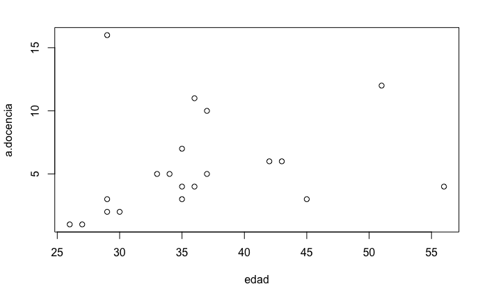

```r
plot(df)
```

```r
library(GGally)
library(Hmisc)
```

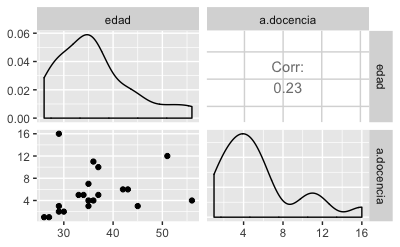

```r
ggpairs(df[,1:2])
```

```r
corrs<-rcorr(as.matrix(df))
corrs
```

```
           edad a.docencia
edad       1.00       0.23
a.docencia 0.23       1.00

n= 20


P
           edad a.docencia
edad            0.33
a.docencia 0.33
```

Asumiendo un valor de significación de 0.05 vemos que no hay correlación entre ambas variales, ya que P valor es 0.33. Hay un 33% de posibilidades de equivocarnos si afirmamos que sí hay relación.

Vamos a ajustar un modelo de regresión lineal simple de la forma Y = b0 + b1*X donde Y=años de docencia y X=edad

```r
Y<-a.docencia
X<-edad
class(X)
```

```
[1] "numeric"
```

```r
#Función para montaje de modelos lineales
lm(Y~X) -> mod_reg  #Y~X quiere decir que queremos explicar Y en función de X
mod_reg
```

```
Call:
lm(formula = Y ~ X)

Coefficients:
(Intercept)            X
     1.3081       0.1156
```

```r
summary(mod_reg)
```

```
Call:
lm(formula = Y ~ X)

Residuals:
    Min      1Q  Median      3Q     Max
-3.7839 -2.6905 -0.9711  0.3180 11.3384

Coefficients:
            Estimate Std. Error t value Pr(>|t|)
(Intercept)   1.3081     4.2789   0.306    0.763
X             0.1156     0.1155   1.001    0.330

Residual standard error: 3.953 on 18 degrees of freedom
Multiple R-squared:  0.05276,   Adjusted R-squared:  0.0001333
F-statistic: 1.003 on 1 and 18 DF,  p-value: 0.33
```

Intercept es B0, que explica el valor de Y cuando X es 0. X en este caso sería B1. Vemos que el error estandard está muy príximo a los coeficientes calculados, lo cual no es buena noticia. El error estándar es significativo. Vemos que los P-Valor o.763 y 0.330, son altos, por lo que la porabilidad de encontra estos valores si aceptamos H0 es alta, por lo que podríamos aceptar H0, es decir que no hay relación.

“H0: There is no relationship between X and Y versus the alternative hypothesis Ha : There is some relationship between X and Y . Mathematically, this corresponds to testing

H0 :β1 =0 Ha :β1 ̸=0 " VER pÄGINA 83 del libro en PDF para entender esto.

El modelo entrenado es muy deficiente porque su R² es muy bajo (un buen modelo debe tener a 1), además ninguno de sus coeficientes es significativamente no nulo.

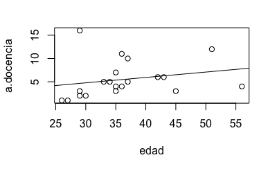

```r
plot(edad,a.docencia)
abline(mod_reg)
```

R^2 también se puede calcular así

```r
cor(edad,a.docencia)^2
```

```
[1] 0.05275786
```

Podemos acceder a los resultados que nos ofrece este modelo de regresión indivudualmente

```r
mod_reg$coefficients
```

```
(Intercept)           X
   1.308086    0.115639
```

```r
mod_reg$coefficients[1]
```

```
(Intercept)
   1.308086
```

```r
mod_reg$residuals
```

```
         1          2          3          4          5          6          7          8          9         10         11         12         13         14
-2.3554512 -3.4303392 -3.3147002 -2.7772562 -0.1241732 -0.1649243  4.7943247  1.6445488 -3.5118413  4.4132707 -0.2805633  5.5289098 -1.4710902 -3.7838703
        15         16         17         18         19         20
11.3383828 -1.3554512 -0.5867293 -1.6616172 -0.2398122 -2.6616172
```

Se puede entrenar un modelo sin el término independiente si en la fórmula restamos 1. Esto tiene sentido si se quiere imponer la restricción en la que cuando X=0, se tiene Y=0

Y=b1*X b0=0

```r
mod_no_intercept<-lm(Y~X-1)
summary(mod_no_intercept)
```

```
Call:
lm(formula = Y ~ X - 1)

Residuals:
    Min      1Q  Median      3Q     Max
-4.4103 -2.3929 -0.9066  0.4688 11.6447

Coefficients:
  Estimate Std. Error t value Pr(>|t|)
X  0.15018    0.02328    6.45  3.5e-06 ***
---
Signif. codes:  0 ‘***’ 0.001 ‘**’ 0.01 ‘*’ 0.05 ‘.’ 0.1 ‘ ’ 1

Residual standard error: 3.858 on 19 degrees of freedom
Multiple R-squared:  0.6865,    Adjusted R-squared:   0.67
F-statistic:  41.6 on 1 and 19 DF,  p-value: 3.499e-06
```

```r
plot(edad,a.docencia)
abline(mod_reg)
```

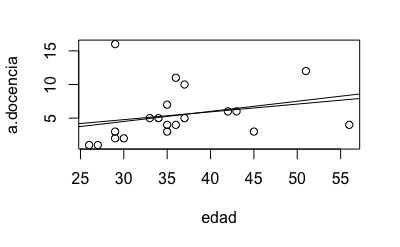

```r
abline(mod_no_intercept)
```

REGRESIÓN POLINOMIAL Este modelo es parabólico ó de grado 2 Y=b2X^2+b1X+b0

[output not shown]